# Spatial-stage snail kite model

Orlando Acevedo-Charry

2026-09-03

# 1 Initial message

To understand better the estimation of a $\lambda$ parameter (asymptotic population growth rate) within a demographic population viability analysis (PVA), I have generated this code following [Hunter & Caswell (2005)](https://doi.org/10.1016/j.ecolmodel.2005.05.002)) manuscript. Although their paper describing the spatial matrix population models that keeps demography and dispersal parameters clearly distinguished is openly available, I struggled to understand the adjustment to the snail kite spatio-demographic PVA. Therefore, many of the text included here belongs to the original paper. I also try to adjust some notation to follow the modeling more clearly in my less advantaged math mind.

# 2 Population Viability Analysis for snail kite (up to 2023)

This section is the original code from the report, adjusted with data up to 2023 by Orlando Acevedo-Charry to estimate the dominant eigenvalue of the projection matrix $\mathbf{A}$ of a matrix population model.

```r
##########################################################
#Spatial PVA for kites template:
#written by Rob Fletcher and Josh Cullen
##########################################################

#set working directory where data are located
#setwd(choose.dir())


library(MASS)
library(expm)   #for matrix powers to calculate growth rate over time
library(tidyverse)
library(wesanderson)
library(future)
library(furrr)
library(zoo) #for rolling sum to determine strings of years


source('R codes/helper functions_rf_new.R')

#################
### Load Data ###
#################

# Survival estimates and Transitions among MUs

##survival_mov_PVA code
surv<- read.csv("data/survival_estimates_PVA_age.droughtXpop.inv.csv") %>%
  mutate(age_cat = case_when(AGE== 'Adult' ~ 'adult',
                             AGE == 'Juvenile' ~ 'juv'))

disp_ad<- read.csv("data/trans_matrix_adults.csv", header = T)
rownames(disp_ad)<- disp_ad$X
disp_ad<- disp_ad[,-1]

new_order <- c("EAST", "EVER", "KRV", "OKEE", "PP", "SJM")

# Reorder both rows and columns
disp_ad <- disp_ad[new_order, new_order]

disp.SE_ad<- read.csv("data/se.trans_matrix_adults.csv", header = T)
rownames(disp.SE_ad)<- disp.SE_ad$X
disp.SE_ad<- disp.SE_ad[,-1]

disp.SE_ad <- disp.SE_ad[new_order, new_order]

disp_juv<- read.csv("data/trans_matrix_juveniles.csv", header = T)
rownames(disp_juv)<- disp_juv$X
disp_juv<- disp_juv[,-1]

disp_juv <- disp_juv[new_order, new_order]

disp.SE_juv<- read.csv("data/se.trans_matrix_juveniles.csv", header = T)
rownames(disp.SE_juv)<- disp.SE_juv$X
disp.SE_juv<- disp.SE_juv[,-1]

disp.SE_juv <- disp.SE_juv[new_order, new_order]

#disp <- read.csv("PVA/trans_noMov.csv")
#rownames(disp)<- disp$X
#disp<- disp[,-1]

#disp.SE <- read.csv("PVA/trans_noMov_se.csv")
#rownames(disp.SE)<- disp.SE$X
#disp.SE<- disp.SE[,-1]


# Reproductive parameters

##Code_nest_success_young_fledged_PVA code
NestSurv <- read.csv("data/PVA_nest_success_estimates.csv", header = T) %>%
  dplyr::rename(MU = Pop,
                spei_cat = spei,
                invaded = inv.cat,
                NS = ns)

##Code_nest_success_young_fledged_PVA code
Nfledge <- read.csv("data/PVA_young_fledged_estimates.csv", header = T) %>%
  dplyr::rename( Yng_cnt.SE = se,
                 MU = Pop,
                 spei_cat = spei,
                 invaded = inv.cat)

#PVA_NA_NM
renesting <- read.csv("data/nest_attempts_PVA.csv", header = T) %>%   #pooled across age
  dplyr::rename(Attempt = mean,
                Attempt.SE = se)


#breedingprob_spei_PVA code
breedprob <- read.csv("data/PVA_breedingprob_est_age_inv.csv", header = T) %>%
  dplyr::rename(Breed = mean,
                spei_cat = spei,
                Breed.SE = se,
                invaded = inv.cat) %>%
  mutate(age_cat = case_when(age_cat== 'A' ~ 'adult',
                             age_cat == 'J' ~ 'juv'))


# Load minimum number of sighted (banded + unbanded) birds per year and MU for K
K.annual <- read.csv("data/min.known.alive.forPVA.2Apr2025.csv") %>%
  dplyr::select(-X)

K.annual<- K.annual %>%
  filter(Year >= 2019)   #subset to only include 2019-present so representative of current conditions (i.e., exotic snails)

#detectability ratio: adjust based on difference between pop estimate and MNKA
K.annual[is.na(K.annual)] <- 0
K.annual$det <- round(rowSums(K.annual[,2:7], na.rm = T)/K.annual$PopSize, 3)
K.annual$det <- ifelse(K.annual$det > 1, 1, K.annual$det) #one year slightly > 1
K.annual[,2:7] <- round(K.annual[,2:7] / K.annual$det, 0)

#proportion for starting distributions
K.annual.prop <- K.annual
K.annual.prop[is.na(K.annual)] <- 0
K.annual.prop <- cbind(K.annual$Year, K.annual.prop[, 2:7] / rowSums(K.annual.prop[, 2:7]))



#####################
### Reformat Data ###
#####################

# Create DF for demographic rates
survNo <- surv %>%
  filter(drought == "No")

survNormal <- survNo %>%
  mutate (spei_cat = case_when (drought == "No" ~ "Normal"))

survWet <- survNo %>%
  mutate (spei_cat = case_when (drought == "No" ~ "Wet"))

survDrought <- surv %>%
  filter(drought == "Yes") %>%
  mutate (spei_cat = case_when (drought == "Yes" ~ "Drought"))

surv2 <- rbind(survDrought, survNormal, survWet)

demo.df<- surv2 %>%
  dplyr::rename(MU = stratum, S = estimate, S.SE = se, S_LCL = lcl, S_UCL = ucl) %>%
  dplyr::select(-X,
                -AGE) %>%
  arrange(MU, spei_cat, age_cat) %>%
  relocate(age_cat, .after = MU)



# Add estimates from repro params
demo.df2<- demo.df %>%
  full_join(., breedprob[,c("MU","spei_cat","age_cat","Breed","Breed.SE", "invaded")],
            by = c("MU","spei_cat","age_cat", "invaded")) %>%  #need to decide what to do with age_cat beacuse they are different form survival
  left_join(., NestSurv[,c("MU","spei_cat","NS","NS_SE","ns_lower","ns_upper", "invaded")],
            by = c("MU","spei_cat", "invaded")) %>%
  left_join(., Nfledge[,c("MU","spei_cat","Yng_cnt","Yng_cnt.SE", "invaded")],
            by = c("MU","spei_cat", "invaded")) %>%
  left_join(., renesting[,c("MU","spei_cat","Attempt","Attempt.SE")],
            by = c("MU","spei_cat")) %>%
  filter(invaded == "Yes") %>%
  dplyr::select(MU, age_cat, spei_cat, S, S.SE, Breed, Breed.SE,
                NS, NS_SE, Yng_cnt, Yng_cnt.SE, Attempt, Attempt.SE)

#Add NA to Attempts (conditional on breeding)
demo.df2$Attempt<- ifelse(is.na(demo.df2$Breed) | demo.df2$Breed == 0, NA, demo.df2$Attempt)
demo.df2$Attempt.SE<- ifelse(is.na(demo.df2$Breed) | demo.df2$Breed == 0, NA, demo.df2$Attempt.SE)

# Replace NAs with imputed values
#We have no information on PP and droughts or wet (there were no droughts or wet after 2018 when Snail Kites colonized) so we use the same breeding probability than for normal years
demo.df2$Breed<- ifelse(demo.df2$MU == "PP" & is.na(demo.df2$Breed),
                        demo.df2$Breed[demo.df2$MU == "PP" & demo.df2$spei_cat == "Normal"],
                        demo.df2$Breed)
demo.df2$Breed.SE<- ifelse(demo.df2$MU == "PP" & is.na(demo.df2$Breed.SE),
                           demo.df2$Breed.SE[demo.df2$MU == "PP" & demo.df2$spei_cat == "Normal"],
                           demo.df2$Breed.SE)
```

```r
#Rest of NA correspond to no individuals breeding so they are 0
demo.df2$Breed<- ifelse(is.na(demo.df2$Breed) | demo.df2$Breed == 0,
                        1e-5,
                        demo.df2$Breed)
demo.df2$Breed.SE<- ifelse(is.na(demo.df2$Breed.SE) | demo.df2$Breed.SE == 0,
                           1e-5,
                           demo.df2$Breed.SE)

#NAs for NS correspond to no nests
demo.df2$NS<- ifelse(is.na(demo.df2$NS) | demo.df2$NS == 0, 1e-5, demo.df2$NS)
demo.df2$NS_SE<- ifelse(is.na(demo.df2$NS_SE) | demo.df2$NS_SE < 1e-5, 1e-5, demo.df2$NS_SE)

#We have no information on PP and droughts or wet (there were no droughts or wet after 2018 when Snail Kites colonized) so we use the same nest attempts than for normal years
demo.df2$Attempt<- ifelse(demo.df2$MU == "PP" & is.na(demo.df2$Attempt),
                          demo.df2$Attempt[demo.df2$MU == "PP" & demo.df2$spei_cat == "Normal"],
                          demo.df2$Attempt)
demo.df2$Attempt.SE<- ifelse(demo.df2$MU == "PP" & is.na(demo.df2$Attempt.SE),
                             demo.df2$Attempt.SE[demo.df2$MU == "PP" & demo.df2$spei_cat == "Normal"],
                             demo.df2$Attempt.SE)

demo.df2$Attempt<- ifelse(is.na(demo.df2$Attempt), 1, demo.df2$Attempt)
demo.df2$Attempt.SE<- ifelse(is.na(demo.df2$Attempt.SE), 0, demo.df2$Attempt.SE)

#NAs for Yng_cnt correspond to no nests
demo.df2$Yng_cnt<- ifelse(is.na(demo.df2$Yng_cnt), 0, demo.df2$Yng_cnt)
demo.df2$Yng_cnt.SE<- ifelse(is.na(demo.df2$Yng_cnt.SE), 0, demo.df2$Yng_cnt.SE)



##############################################
#   DEFINE DEMOGRAPHY AND MOVEMENT RATES     #
##############################################

# Set key features of population
Np <- 6 # Number of patches
Ns <- 2 # Number of stages

#------------------------------------------#
# Build the vec-permutation matrix (eq 9)
#------------------------------------------#

P <- matrix(0, Ns*Np, Ns*Np)

for (i in 1:Ns){
  for (j in 1:Np){
    E <- matrix(0,Ns,Np)
    E[i,j] <- 1
    P <- P + kronecker(E,t(E))
  }
}



##########################################################################
##########################################################################
#Population Projections over observed time intervals
##########################################################################
##########################################################################

#1000 total reps: Nrep * Nclimaterep: 20*50 = 1000

Nrep <- 10  # number of draws from demographic rates. OAC changed this from 20
Nstart2023 <- 1410  # adult females in 2023
#Nstart2024 <- round(2007/2,0) #adult females in 2024

#Number of projected years
t <- 10             # year 1 is start year (i.e., 2024). OAC changed this from 31, because we want here the deterministic lambdas
Nclimaterep <- 10   #random draws of climate categories. OAC changed this from 50

take <- c(0, 0.2, 0.5) #c(0,0.1,0.2,0.3,0.4,0.5)
nTake <- length(take)



###############################
# SPEI and Drought Setup (Baseline Only)
###############################

set.seed(123)
spei.proj <- vector("list", Nclimaterep)
for(i in 1:Nclimaterep){
  spei.proj[[i]] <- data.frame(baseline = sample(c("Drought", "Normal", "Wet"),
                                                 t, replace = TRUE,
                                                 prob = c(0.09, 0.84, 0.07))) #This is the frequency of extreme values in the past years (i.e., no change in climate scenario for the future)

}


###############################
# PREPARE STORAGE FOR RESULTS
###############################



sim_results <- vector("list", Nclimaterep)
for(j in 1:Nclimaterep){
  sim_results[[j]] <- vector("list", Nrep)
  for(k in 1:Nrep){
    sim_results[[j]][[k]] <- vector("list", nTake)
    names(sim_results[[j]][[k]]) <- paste0("take_", take)
  }
}

# Create parallel storage for carrying capacity values
Klow_store <- vector("list", Nclimaterep)
for(j in 1:Nclimaterep){
  Klow_store[[j]] <- vector("list", Nrep)
  for(k in 1:Nrep){
    Klow_store[[j]][[k]] <- vector("list", nTake)
    names(Klow_store[[j]][[k]]) <- paste0("take_", take)
  }
}


# storage for the MU “take” at time = 1
take_store <- vector("list", Nclimaterep)
for(j in seq_len(Nclimaterep)) {
  take_store[[j]] <- vector("list", Nrep)
  for(k in seq_len(Nrep)) {
    take_store[[j]][[k]] <- vector("list", nTake)
    names(take_store[[j]][[k]]) <- paste0("take_", take)
  }
}

# Define the names for the new multiplier scenarios:
multiplier_names <- c("optimistic", "status_quo", "pessimistic")

MU_names <- c("EAST", "EVER", "KRV", "OKEE", "PP", "SJM")

###################################
### Run matrix projection model ###
###################################

# Deterministic lambda per patch
lambda_patch_store <- list()

# Deterministic lambda for the metapopulation
lambda_meta_store <- list()


#loop through SPEI replicates
for (j in 1:Nclimaterep) {
  #loop through replicate demographic draws
  for (k in 1:Nrep) {

    #random draw of starting distribution based on 2019-2023 distributions
    MU.prop<- K.annual.prop[sample(nrow(K.annual.prop), size = 1), 2:7]

    #In case we want to use the 2023 distributions
    #MU.prop_2023<- K.annual.prop[5, 2:7]

    #EAST, EVER, KRV, OKEE, PP, SJM
    Na <- round(Nstart2023 * MU.prop * 0.8) #80% adults
    Nj <- round(Nstart2023 * MU.prop * 0.2) #20% sub-adults
    N <-  t(rbind(Nj, Na))

    # Random draw of carrying capacity for rep (2019-2023)
    year.ind<- sample(x = 2019:2023, size = t, replace = TRUE)

    #create matrix of K for MU x t; randomly sample from distribution based on year
    K<- sapply(year.ind, function(x) K.annual[K.annual$Year == x, c(2:7)] / 2)  #divide by 2 to account only for females
    K<- matrix(unlist(K), nrow = 6, ncol = t, byrow = FALSE)  #convert from list to matrix
    K[is.na(K)]<- 0  #change NAs to 0


    # Loop over each "take" value
    for (n in 1:nTake) {
      # Distribute "take" proportionally among MUs:
      floaters_1 <- round(take[n] * Nstart2023 * MU.prop, 0)
```

```r
      state0 <- N #starting population size is the same for all take scenarios
      state0_vec <- as.vector(t(state0))

      # Create extra lists in storage for the multiplier scenarios:
      sim_results[[j]][[k]][[n]] <- list()
      #store carrying capacity
      Klow_store[[j]][[k]][[n]] <- list()
      # store the number removed per MU
      take_store[[j]][[k]][[n]] <- floaters_1

      ###########################
      # Now loop over multiplier scenarios
      ###########################
      for (p in seq_along(multiplier_names)) {
        mult_name <- multiplier_names[p]
        # Draw a multiplier from the appropriate range:
        if(mult_name == "optimistic"){
          mult_val <- 1.25
        } else if(mult_name == "status_quo"){
          mult_val <- 1
        } else if(mult_name == "pessimistic"){
          mult_val <- 0.75
        }

        # Compute Klow for this scenario:
        Klow <- round(mult_val * K, 0)
        # Preallocate a matrix to store the Klow values used at each time step:
        Klow_used <- matrix(NA, nrow = Np, ncol = t)


        sim_state_take <- matrix(NA, nrow = Np * Ns, ncol = t)
        sim_state_take[,1] <- state0_vec #starting size at t =1


        #loop through time
        for (i in 2:t) {

          print(c( j, k, take[n], mult_name, i))

          #create matrices for breeding/survival and dispersal
          B.t <- getB(x = demo.df2, spei = spei.proj[[j]]$baseline[i]) #function for creating B matrix
          B.t.float <- getB_floater(x = demo.df2, spei = spei.proj[[j]]$baseline[i]) #function for creating B matrix

          # OAC: Deterministic lambda for each patch
          for(h in 1:Np){
            idx <- ((h-1)*Ns + 1):(h*Ns)
            B.patch <- B.t[idx, idx]
            eigB <- eigen(B.patch)
            lambda_patch <- Re(
              eigB$values[which.max(Re(eigB$values))]
            )
            lambda_patch_store[[length(lambda_patch_store)+1]] <-
              data.frame(
                climate_rep = j,
                dem_rep     = k,
                take        = take[n],
                management  = mult_name,
                year        = i,
                MU          = MU_names[h],
                lambda_patch = lambda_patch
              )
          }

          #dispersal matrix:
          M.t <- getM2(disp_ad = t(disp_ad), disp_ad.SE = t(disp.SE_ad),
                       disp_juv = t(disp_juv), disp_juv.SE = t(disp.SE_juv))

          #M.t <- getM(disp = t(disp), disp.SE = t(disp.SE))
          # Store Klow for this time step:
          Klow_used[, i] <- Klow[, i]

          #vec permutation: demography then dispersal by pop vector by *patches*
          A.t <- t(P) %*% M.t %*% P %*% B.t
          A.t.float <- t(P) %*% M.t %*% P %*% B.t.float

          # OAC: Deterministic lambda for the metapopulation
          eigA <- eigen(A.t)
          lambda_meta <- Re(eigA$values[which.max(Re(eigA$values))])
          lambda_meta_store[[length(lambda_meta_store) + 1]] <- data.frame(
            climate_rep = j,
            dem_rep     = k,
            take        = take[n],
            management  = mult_name,
            year        = i,
            lambda_meta = lambda_meta
          )

          #vec permutation: demography then dispersal by pop vector by *stages*
          #A.t <-  M.t %*% P %*% B.t %*% t(P)

          # Get population at previous time step and reshape into MU x stage matrix
          state_prev <- round(sim_state_take[, i - 1], 0)
          state_prev_mat <- matrix(state_prev, nrow = Np, ncol = Ns, byrow = TRUE)
          total_prev <- rowSums(state_prev_mat)

          # floaters from K:
          flo_K <- total_prev - Klow[,i]  #if positive, above carrying capacity->floaters
          flo_K[flo_K < 0 ] <- 0

          # floaters from "take" only applies at i=2:
          flo_all <- if(i==2) flo_K + floaters_1 else flo_K

          breeders <- as.numeric(total_prev - flo_all)
          breeders[breeders < 0 ] <- 0
          breed_frac <- breeders / total_prev
          breed_frac[is.nan(breed_frac)] <- 0


          #get number of breeders and floaters
          ns.mat.breeder <- state_prev_mat * breed_frac #applies to juv/adults
          ns.mat.breeder[is.nan(ns.mat.breeder)] <- 0
          ns.mat.breeder.vec <- round(as.vector(t(ns.mat.breeder)),0)
          ns.mat.floater <- state_prev_mat - ns.mat.breeder
          ns.mat.floater.vec <- round(as.vector(t(ns.mat.floater)),0)


          #project new pop size based on demographics of floaters/breeders
          N.t.i.breed <- A.t %*%  ns.mat.breeder.vec
          N.t.i.float <- A.t.float %*% ns.mat.floater.vec

          #sum
          sim_state_take[,i] <- round(N.t.i.breed + N.t.i.float,0)

        }#end for i

        # Summarize Results for This "Take" Value
        # Aggregate across stages to get total MU population per time step.
        MU_pop <- matrix(NA, nrow = Np, ncol = t)
        for (i in 1:t) {
          state_i <- sim_state_take[, i]
          state_i_mat <- matrix(state_i, nrow = Np, ncol = Ns, byrow = TRUE)
          MU_pop[, i] <- rowSums(state_i_mat)
        }

        # Store the MU x time matrix for this replicate and take value.
        sim_results[[j]][[k]][[n]][[mult_name]] <- MU_pop

        # Store the Klow matrix for this replicate and take:
        Klow_store[[j]][[k]][[n]][[mult_name]] <- Klow_used

      }#end for p

    }#end for n

  } #end for k

} #end for j

# Recovery Deterministic lambdas
df_lambda_meta <- bind_rows(lambda_meta_store)
df_lambda_patch <- bind_rows(lambda_patch_store)

saveRDS(df_lambda_meta, file = "data/df_lambda_meta.RDS")
saveRDS(df_lambda_patch, file = "data/df_lambda_patch.RDS")

#the final part of this code is for the figures, so I cut it here and leave it for now.
```

I reduced some values to make quick computation. In addition, I saved the deterministic $\lambda$ (per patch $\lambda_{\mathbf{B}_{h}}$ and for the metapopulation $\lambda_{\mathbf{A}}$) to have the values below.

```r
library(tidyverse)
lambda_metaP <- readRDS(here::here("data/df_lambda_meta.RDS")) %>%  # the here::here() anchors the file paths to the main project root, no matter where the .Rmd file is sitting.
  mutate(take = factor(take, levels = c("0", "0.2", "0.5"),
                             labels = c("0%", "20%", "50%"))) |>
  filter(management == "status_quo")

lambda_patchB <- readRDS(here::here("data/df_lambda_patch.RDS")) %>%
  mutate(take = factor(take, levels = c("0", "0.2", "0.5"),
                             labels = c("0%", "20%", "50%"))) |>
  filter(management == "status_quo")

mean_lambda_A <- lambda_metaP |>
  summarise(mean_lambda_A = mean(lambda_meta),
            .groups = "drop")
mean_lambda_A
```

```
##   mean_lambda_A
## 1      1.034873
```

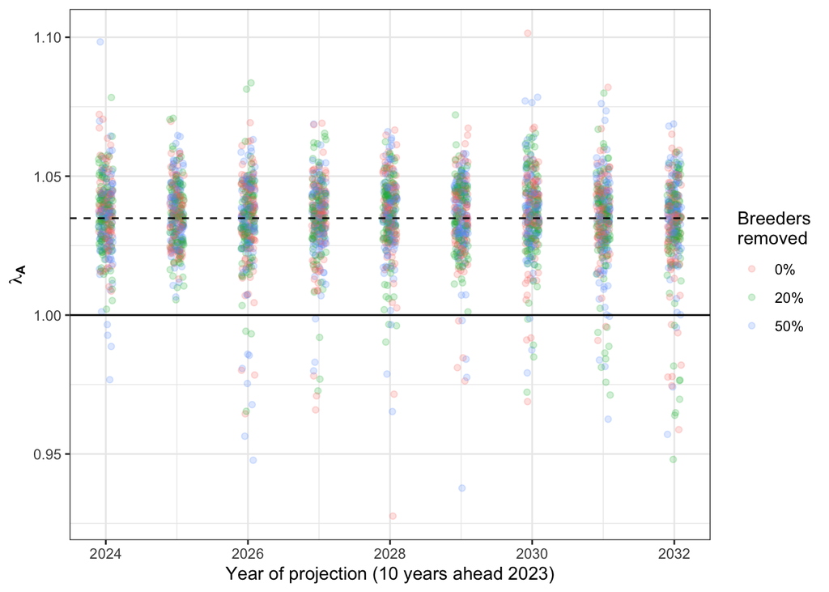

```r
ggplot(lambda_metaP, aes(x = year + 2022,
                         y = lambda_meta,
                         color = take)) +
  geom_jitter(alpha = 0.2, width = 0.1) +
  geom_hline(yintercept = 1, lty = 1) +
  geom_hline(data = mean_lambda_A, yintercept = mean_lambda_A$mean_lambda_A, lty = 2) +
  labs(x = "Year of projection (10 years ahead 2023)",
       y = expression(lambda[bold(A)]),
       color = "Breeders\nremoved") +
  theme_bw() +
  theme(strip.background = element_blank())
```

```r
mean_lambda_B <- lambda_patchB |>
  group_by(MU) |>
  summarise(mean_lambda_B = mean(lambda_patch))
mean_lambda_B
```

```
## # A tibble: 6 × 2
##   MU    mean_lambda_B
##   <chr>         <dbl>
## 1 EAST          0.872
## 2 EVER          1.09
## 3 KRV           1.05
## 4 OKEE          0.946
## 5 PP            1.03
## 6 SJM           1.12
```

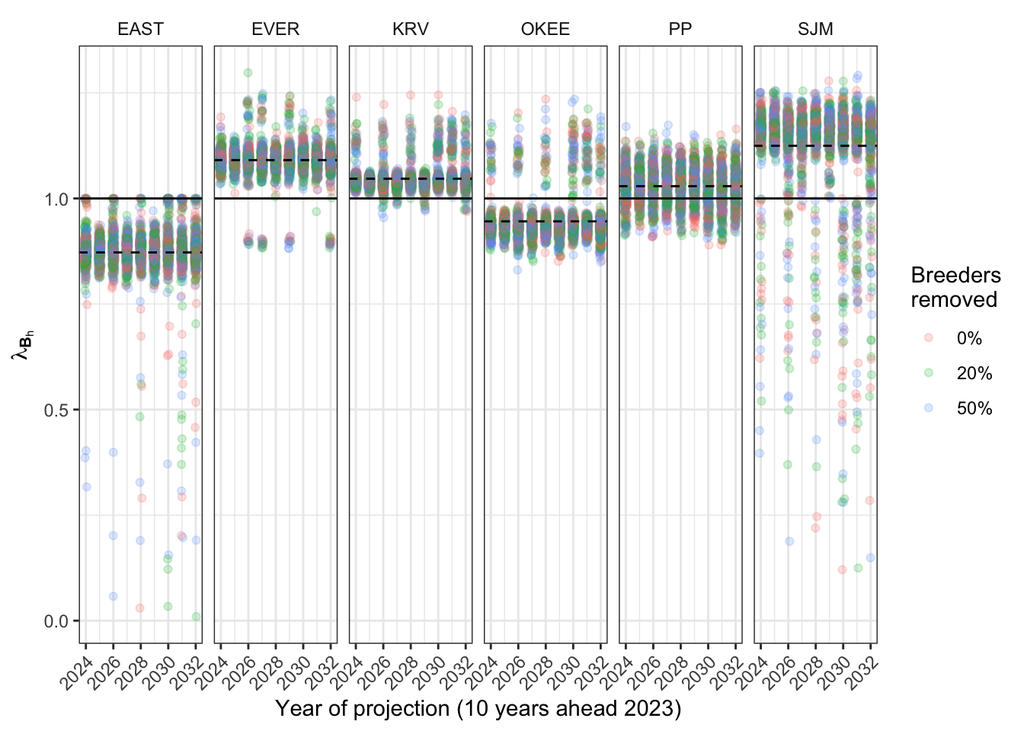

```r
ggplot(lambda_patchB, aes(x = year + 2022,
                         y = lambda_patch,
                         color = take)) +
  facet_grid(~MU) +
  geom_jitter(alpha = 0.2, width = 0.1) +
  geom_hline(yintercept = 1, lty = 1) +
  geom_hline(data = mean_lambda_B, aes(yintercept = mean_lambda_B), lty = 2) +
  labs(x = "Year of projection (10 years ahead 2023)",
       y = expression(lambda[bold(B)[h]]),
       color = "Breeders\nremoved") +
  theme_bw() +
  theme(strip.background = element_blank(), axis.text.x = element_text(angle = 45, hjust = 1, vjust = 1))
```

But, how this model was elaborated? How we can improved/updated? In what follows, I will try to understand the spatial and demographically structured matrix population model from the perspective of our snail kite project.

# 3 Spatial and demographically structured matrix population model

Snail kites are segregated spatially in Florida as a metapopulation. The species are also demographically categorized in different stages. Let $H$ be the number of patches ($h = 1, 2, \dots, H$) and $S$ be the number of stages ($s = 1,2,...,S$). The matrix model describing the population can be $\mathbf{n}(t+1) = \mathbf{A}\mathbf{n}(t)$, with the vector $\mathbf{n}$ including densities (abundance, counts) of each patch or each stage at time $t$. The projection matrix, $\mathbf{A}$, includes demographic and/or dispersal processes, with the asymptotic population growth rate, $\lambda$, being the dominant eigenvalue of $\mathbf{A}$.

Following [Hunter & Caswell (2005)](https://doi.org/10.1016/j.ecolmodel.2005.05.002)), the state of the population can be described by the matrix:

$$\mathbf{N}(t) = \begin{pmatrix}
n_{1,1} & n_{1,2} & ... & n_{1,H} \\
n_{2,1} & n_{2,2} & ... & n_{2,H} \\
\vdots & \vdots & \ddots & \vdots \\
n_{S,1} & n_{S,2} & ... & n_{S,H}
\end{pmatrix}(t)$$

In the specific case of snail kites, $n_{s,h}$ can be the detection-corrected minimum known to be alive abundance of stage $s$ in patch $h$ at time $t$. The population vector $\mathbf{n}$ can be seen as the stages or patches arrangement of $\mathbf{N}$:

$$\mathbf{n}_{\text{patches}} = \begin{pmatrix}
\mathbf{n}_1 \\
\vdots \\
\mathbf{n}_H
\end{pmatrix}
=
\begin{pmatrix}
\begin{bmatrix}
n_{1,1} \\ n_{2,1} \\ \vdots \\ n_{S,1}
\end{bmatrix} \\
\begin{bmatrix}
\vdots \\
\end{bmatrix} \\
\begin{bmatrix}
n_{1,H} \\ n_{2,H} \\ \vdots \\ n_{S,H}
\end{bmatrix}
\end{pmatrix}$$

Note that the subvectors give the stage distribution within each patch $h$. Complementary, the subvectors in the stages arrangement give the spatial distribution of each stage $s$.

$$\mathbf{n}_{\text{stages}} = \begin{pmatrix}
\mathbf{n}_1 \\
\vdots \\
\mathbf{n}_S
\end{pmatrix} = \begin{pmatrix}
\begin{bmatrix}
n_{1,1} & n_{1,2} & \cdots & n_{1,H} \\
\end{bmatrix} \\
\begin{bmatrix}
\cdots \\
\end{bmatrix} \\
\begin{bmatrix}
n_{S,1} & n_{S,2} & \cdots & n_{S,H}
\end{bmatrix}
\end{pmatrix}$$

The transposed matrix is more similar (convenient?) to the $\mathbf{n}_{\text{patches}}$:

$$\mathbf{n}_{\text{stages}} = \begin{pmatrix}
\mathbf{n}_1^\top \\
\vdots \\
\mathbf{n}_S^\top
\end{pmatrix} = \begin{pmatrix}
\begin{bmatrix}
n_{1,1} \\ n_{1,2} \\ \vdots \\ n_{1,H} \\
\end{bmatrix} \\
\begin{bmatrix}
\vdots \\
\end{bmatrix} \\
\begin{bmatrix}
n_{S,1} \\ n_{S,2} \\ \cdots \\ n_{S,H}
\end{bmatrix}
\end{pmatrix}$$

## 3.1 Model demography without dispersal

Let $\mathbf{B}_h$ be the $s \times s$ demographic projection matrix for patch $h$ (Lefkovitch matrix), the matrix model describing the population for this patch is $\mathbf{n}_h(t+1) = \mathbf{B}_h\mathbf{n}_h(t)$. Without dispersal, the metapopulation would be projected by a block diagonal matrix $\mathbb{B}$. Lets use four potential stages in snail kites (1: juvenile $<1$ year, 2: young adult $1$ to $2$ years, 3: adult $>2$ but $≤12$, and 4: old adult $>12$; slightly adjusted from: young of the year (G, G-A, G-C, G-D), juvenile, boy, adult, old) and the six “patches” (1: EVER, 2: OKEE, 3: EAST, 4: KRV, 5: SJM, and 6: PP):

$$\begin{pmatrix}
\mathbf{n}_1 \\
\mathbf{n}_2 \\
\mathbf{n}_3 \\
\mathbf{n}_4 \\
\mathbf{n}_5 \\
\mathbf{n}_6
\end{pmatrix} (t + 1) = \begin{pmatrix}
\mathbf{B}_1 & 0 & \cdots & 0 \\
0 & \mathbf{B}_2 & \cdots & 0 \\
\vdots & \vdots & \ddots & \vdots \\
0 & 0 & \cdots & \mathbf{B}_H
\end{pmatrix} \times
\begin{pmatrix}
\mathbf{n}_1 \\
\mathbf{n}_2 \\
\mathbf{n}_3 \\
\mathbf{n}_4 \\
\mathbf{n}_5 \\
\mathbf{n}_6
\end{pmatrix}(t)$$

Or:
$$\begin{pmatrix}
\begin{bmatrix}
n_{1,1} \\ n_{2,1} \\ n_{3,1} \\ n_{4,1}
\end{bmatrix} \\
\begin{bmatrix}
\vdots \\
\end{bmatrix} \\
\begin{bmatrix}
n_{1,6} \\ n_{2,6} \\ n_{3,6} \\ n_{4,6}
\end{bmatrix}
\end{pmatrix} (t + 1) = \begin{pmatrix}
\mathbf{B}_1 = \begin{bmatrix}
0 & F_2 & F_3 & F_4 \\
\phi_1 & 0 & 0 & 0 \\
0 & \phi_2 & \phi_3(1-\gamma_3) & 0 \\
0 & 0 & \phi_3 \gamma_3 & \phi_4
\end{bmatrix}_1 & 0 & \cdots & 0 \\
0 & \mathbf{B}_2 & \cdots & 0 \\
\vdots & \vdots & \ddots & \vdots \\
0 & 0 & \cdots & \mathbf{B}_H
\end{pmatrix} \times
\begin{pmatrix}
\begin{bmatrix}
n_{1,1} \\ n_{2,1} \\ n_{3,1} \\ n_{4,1}
\end{bmatrix} \\
\begin{bmatrix}
\vdots \\
\end{bmatrix} \\
\begin{bmatrix}
n_{1,6} \\ n_{2,6} \\ n_{3,6} \\ n_{4,6}
\end{bmatrix}
\end{pmatrix}(t)$$
where
$$\mathbb{B} = \begin{pmatrix}
\mathbf{B}_1 = \begin{bmatrix}
0 & F_2 & F_3 & F_4 \\
\phi_1 & 0 & 0 & 0 \\
0 & \phi_2 & \phi_3(1-\gamma_3) & 0 \\
0 & 0 & \phi_3 \gamma_3 & \phi_4
\end{bmatrix}_1 & 0 & \cdots & 0 \\
0 & \mathbf{B}_2 & \cdots & 0 \\
\vdots & \vdots & \ddots & \vdots \\
0 & 0 & \cdots & \mathbf{B}_H
\end{pmatrix}$$
and the elements within $\mathbf{B}_h$ represents different population parameters. Let’s begin with the transitions subdiagonals $G_s$ of the Lefkovitch matrix, which can be parameterized as $G_s = \phi_s \gamma_s$, where $\phi_s$ is annual survivorship and $\gamma_s$ is the probability of advancing to the next stage given survival. Stage 1 and 2 are fixed in time, so an individual surviving a year in stage 1 **must** enter stage 2 and an individual surviving a year in stage 2 **must** enter state 3; transitions $G_1$ and $G_2$ in the Lefkovitch matrix is represented by the annual survival $\phi_1$ and $\phi_2$, respectability. In stage 3 (2-12 yr), an individual can survive and remain in stage 3, can survive and become >12 (stage 4), or can die. This transition is parameterized as $G_3 = \phi_3 \gamma_3$. Stage 4 is the terminal stage, so there is no “transition” ($G_4 = 0$). The conditions of our stage means that the diagonal of stage survival probability $Q_s$ (the probability to stay at stage $s$; $Q_s = \phi_s (1 - \gamma_s)$) is 0 for stages 1 and 2. In stage 3, this stage survival probability becomes $Q_3 = \phi_3 (1-\gamma_3)$ (the individual survive stage 3 and does not transition to stage 4). Because individuals in the terminal stage (4) do not transition to a next stage, the stage survival probability is the annual survival probability $Q_4 = \phi_4$. Finally, we have the fertility. Evidently, individuals within stage 1 ($<1$ year) do not have fertility, so $F_1 = 0$. The fertility of the different stages from 2 to 4 is represented by $F_2$, $F_3$, and $F_4$.

This model can be simplify to include only two stages: 1) juveniles without reproduction and 2) adults:
$$\begin{pmatrix}
\begin{bmatrix}
n_{1,1} \\ n_{2,1}
\end{bmatrix} \\
\begin{bmatrix}
\vdots \\
\end{bmatrix} \\
\begin{bmatrix}
n_{1,6} \\ n_{2,6}
\end{bmatrix}
\end{pmatrix} (t + 1) = \begin{pmatrix}
\mathbf{B}_1 = \begin{bmatrix}
0 & F_2 \\
\phi_1 & \phi_2 (1 - \gamma)
\end{bmatrix}_1 & 0 & \cdots & 0 \\
0 & \mathbf{B}_2 & \cdots & 0 \\
\vdots & \vdots & \ddots & \vdots \\
0 & 0 & \cdots & \mathbf{B}_H
\end{pmatrix} \times
\begin{pmatrix}
\begin{bmatrix}
n_{1,1} \\ n_{2,1}
\end{bmatrix} \\
\begin{bmatrix}
\vdots \\
\end{bmatrix} \\
\begin{bmatrix}
n_{1,6} \\ n_{2,6}
\end{bmatrix}
\end{pmatrix}(t)$$

And even further simplified with only two regions (e.g., north and south):

$$\begin{pmatrix}
\begin{bmatrix}
n_{1,1} \\ n_{2,1}
\end{bmatrix} \\
\begin{bmatrix}
n_{1,2} \\ n_{2,2}
\end{bmatrix}
\end{pmatrix} (t + 1) = \begin{pmatrix}
\mathbf{B}_1 = \begin{bmatrix}
0 & F_2 \\
\phi_1 & \phi_2 (1 - \gamma)
\end{bmatrix}_1 & 0 \\
0 & \mathbf{B}_2
\end{pmatrix} \times
\begin{pmatrix}
\begin{bmatrix}
n_{1,1} \\ n_{2,1}
\end{bmatrix} \\
\begin{bmatrix}
n_{1,2} \\ n_{2,2}
\end{bmatrix}
\end{pmatrix}(t)$$

Annual survival $\phi_{s,h}$ (and detection probability $p_{s,h}$) can be estimated with a multistate Capture-Mark-Recapture model. Adding stage transitions to this model, we can estimate the probability of advancing stages given survival in the previous stage $\gamma$ (growing). Fertility can be estimated with the breeding probability or with an integrated population model.

## 3.2 Model dispersal without demography

Let $\mathbf{M}_s$ be the $h \times h$ dispersal matrix for stage $s$, so that $m_{ij}^{(s)}$ is the probability that an individual of stage $s$ moves from patch $j$ to patch $i$. Then dispersal would be described by a block diagonal matrix $\mathbb{M}$. Again, lets use the four potential stages in snail kites (1: young of the year $<1$ year, 2: young adult $1$ to $2$ years, 3: adult $>2$ but $≤12$, and 4: old adult $>12$) and the six “patches” (1: EVER, 2: OKEE, 3: EAST, 4: KRV, 5: SJM, and 6: PP):

$$\begin{pmatrix}
\mathbf{n}_1^\top \\
\mathbf{n}_2^\top \\
\mathbf{n}_3^\top \\
\mathbf{n}_4^\top
\end{pmatrix} (t + 1)
= \begin{pmatrix}
\mathbf{M}_1 & 0 & \cdots & 0 \\
0 & \mathbf{M}_2 & \cdots & 0 \\
\vdots & \vdots & \ddots & \vdots \\
0 & 0 & \cdots & \mathbf{M}_S
\end{pmatrix} \times
\begin{pmatrix}
\mathbf{n}_1^\top \\
\mathbf{n}_2^\top \\
\mathbf{n}_3^\top \\
\mathbf{n}_4^\top
\end{pmatrix}(t)$$

Or:
$$\begin{pmatrix}
\begin{bmatrix}
n_{1,1} \\ n_{1,2} \\ n_{1,3} \\ n_{1,4} \\ n_{1,5} \\ n_{1,6}
\end{bmatrix} \\
\begin{bmatrix}
\vdots \\
\end{bmatrix} \\
\begin{bmatrix}
n_{4,1} \\ n_{4,2} \\ n_{4,3} \\ n_{4,4} \\ n_{4,5} \\ n_{4,6}
\end{bmatrix}
\end{pmatrix} (t + 1) = \begin{pmatrix}
\mathbf{M}_1 = \begin{bmatrix}
m_{1,1} & m_{1,2} & m_{1,3} & m_{1,4} & m_{1,5} & m_{1,6} \\
m_{2,1} & m_{2,2} & m_{2,3} & m_{2,4} & m_{2,5} & m_{2,6} \\
m_{3,1} & m_{3,2} & m_{3,3} & m_{3,4} & m_{3,5} & m_{3,6} \\
m_{4,1} & m_{4,2} & m_{4,3} & m_{4,4} & m_{4,5} & m_{4,6} \\
m_{5,1} & m_{5,2} & m_{5,3} & m_{5,4} & m_{5,5} & m_{5,6} \\
m_{6,1} & m_{6,2} & m_{6,3} & m_{6,4} & m_{6,5} & m_{6,6} \\
\end{bmatrix}_1 & 0 & \cdots & 0 \\
0 & \mathbf{M}_2 & \cdots & 0 \\
\vdots & \vdots & \ddots & \vdots \\
0 & 0 & \cdots & \mathbf{M}_S
\end{pmatrix} \times
\begin{pmatrix}
\begin{bmatrix}
n_{1,1} \\ n_{1,2} \\ n_{1,3} \\ n_{1,4} \\ n_{1,5} \\ n_{1,6}
\end{bmatrix} \\
\begin{bmatrix}
\vdots \\
\end{bmatrix} \\
\begin{bmatrix}
n_{4,1} \\ n_{4,2} \\ n_{4,3} \\ n_{4,4} \\ n_{4,5} \\ n_{4,6}
\end{bmatrix}
\end{pmatrix}(t)$$

where
$$\mathbb{M} = \begin{pmatrix}
\mathbf{M}_1 = \begin{bmatrix}
m_{1,1} & m_{1,2} & m_{1,3} & m_{1,4} & m_{1,5} & m_{1,6} \\
m_{2,1} & m_{2,2} & m_{2,3} & m_{2,4} & m_{2,5} & m_{2,6} \\
m_{3,1} & m_{3,2} & m_{3,3} & m_{3,4} & m_{3,5} & m_{3,6} \\
m_{4,1} & m_{4,2} & m_{4,3} & m_{4,4} & m_{4,5} & m_{4,6} \\
m_{5,1} & m_{5,2} & m_{5,3} & m_{5,4} & m_{5,5} & m_{5,6} \\
m_{6,1} & m_{6,2} & m_{6,3} & m_{6,4} & m_{6,5} & m_{6,6} \\
\end{bmatrix}_1 & 0 & \cdots & 0 \\
0 & \mathbf{M}_2 & \cdots & 0 \\
\vdots & \vdots & \ddots & \vdots \\
0 & 0 & \cdots & \mathbf{M}_S
\end{pmatrix}$$

and the elements within $\mathbf{M}_s$ represents movement probability across patches.

In the very simplified model (2 stages and 2 patches), we have:

$$\begin{pmatrix}
\begin{bmatrix}
n_{1,1} \\ n_{1,2}
\end{bmatrix} \\
\begin{bmatrix}
n_{2,1} \\ n_{2,2}
\end{bmatrix}
\end{pmatrix} (t + 1) = \begin{pmatrix}
\mathbf{M}_1 = \begin{bmatrix}
m_{1,1} & m_{1,2} \\
m_{2,1} & m_{2,2}
\end{bmatrix}_1 & 0 \\
0 & \mathbf{M}_2
\end{pmatrix} \times
\begin{pmatrix}
\begin{bmatrix}
n_{1,1} \\ n_{1,2}
\end{bmatrix} \\
\begin{bmatrix}
n_{2,1} \\ n_{2,2}
\end{bmatrix}
\end{pmatrix}(t)$$

## 3.3 Incorporating demography and dispersal with the vec operartor

Reconstructing a model that maintains the block diagonal forms of the demography and dispersal matrices requires converting a population vector organized by patches into a population vector organizes by stages and vice versa:

$$\mathbf{n}_{\text{patches}} = \text{vec}(\textbf{N}) \\
\mathbf{n}_{\text{stages}} = \text{vec}(\textbf{N}^\top)$$

And these vectors are related by the *vec-permutation matrix* $\mathbf{P}$
$$\text{vec}(\textbf{N}^\top) = \mathbf{P}\ \text{vec}(\textbf{N})$$

To me, it is easier to understand this by seeing in the matrix form in detail. The matrix $\mathbf{N}$ (for snail kites in Florida) is:

$$\mathbf{N} = \begin{pmatrix}
n_{1,1} & n_{1,2} & n_{1,3} & n_{1,4} & n_{1,5} & n_{1,6} \\
n_{2,1} & n_{2,2} & n_{2,3} & n_{2,4} & n_{2,5} & n_{2,6} \\
n_{3,1} & n_{3,2} & n_{3,3} & n_{3,4} & n_{3,5} & n_{3,6} \\
n_{4,1} & n_{4,2} & n_{4,3} & n_{4,4} & n_{4,5} & n_{4,6}
\end{pmatrix}$$

Recall each row is a stage and each column is a patch. The “transposed” matrix is:

$$\mathbf{N}^\top = \begin{bmatrix}
n_{1,1} & n_{2,1} & n_{3,1} & n_{4,1} \\
n_{1,2} & n_{2,2} & n_{3,2} & n_{4,2} \\
n_{1,3} & n_{2,3} & n_{3,3} & n_{4,3} \\
n_{1,4} & n_{2,4} & n_{3,4} & n_{4,4} \\
n_{1,5} & n_{2,5} & n_{3,5} & n_{4,5} \\
n_{1,6} & n_{2,6} & n_{3,6} & n_{4,6}
\end{bmatrix}$$

The $\text{vec}$ operator stacks the columns of a matrix one on top of the other. Something like:

$$\text{vec}(\mathbf{N}) = \begin{pmatrix}
n_{1,1} \\
n_{2,1} \\
n_{3,1} \\
n_{4,1} \\
n_{1,2} \\
n_{2,2} \\
n_{3,2} \\
n_{4,2} \\
n_{1,3} \\
n_{2,3} \\
n_{3,3} \\
n_{4,3} \\
n_{1,4} \\
n_{2,4} \\
n_{3,4} \\
n_{4,4} \\
n_{1,5} \\
n_{2,5} \\
n_{3,5} \\
n_{4,5} \\
n_{1,6} \\
n_{2,6} \\
n_{3,6} \\
n_{4,6}
\end{pmatrix};\
\text{vec}(\mathbf{N}^\top) = \begin{bmatrix}
n_{1,1} \\
n_{1,2} \\
n_{1,3} \\
n_{1,4} \\
n_{1,5} \\
n_{1,6} \\
n_{2,1} \\
n_{2,2} \\
n_{2,3} \\
n_{2,4} \\
n_{2,5} \\
n_{2,6} \\
n_{3,1} \\
n_{3,2} \\
n_{3,3} \\
n_{3,4} \\
n_{3,5} \\
n_{3,6} \\
n_{4,1} \\
n_{4,2} \\
n_{4,3} \\
n_{4,4} \\
n_{4,5} \\
n_{4,6}
\end{bmatrix}$$

while the vec-permutation matrix $\mathbf{P}$ has dimension $s,h \times s,h$, given by:

$$\mathbf{P}(s, h) = \sum_{s = 1}^{S} \sum_{h = 1}^H \mathbf{E}_{s,h} \otimes \mathbf{E}_{s,h}^\top$$

The matrix $\mathbf{E}$ has dimensions $s \times h$, with a 1 in the $s,h$ position and zeros elsewhere. The $\otimes$ is the Kronecker matrix product (If $\mathbf{A}$ is an $m \times n$ matrix and $\mathbf{B}$ is a $p \times q$ matrix, then the Kronecker product $\mathbf{A} \otimes \mathbf{B}$ is the $pm \times qn$ block matrix, [see](https://en.wikipedia.org/wiki/Kronecker_product)).

Let see a potential example of $\mathbf{E}$ and the Kronecker product, when $s = 1$ and $h = 2$:

$$\mathbf{E} = \begin{pmatrix}
0 & 1 & 0 & 0 & 0 & 0\\
0 & 0 & 0 & 0 & 0 & 0\\
0 & 0 & 0 & 0 & 0 & 0\\
0 & 0 & 0 & 0 & 0 & 0
\end{pmatrix} ;\ \mathbf{E}^\top = \begin{pmatrix}
0 & 0 & 0 & 0 \\
1 & 0 & 0 & 0 \\
0 & 0 & 0 & 0 \\
0 & 0 & 0 & 0 \\
0 & 0 & 0 & 0 \\
0 & 0 & 0 & 0
\end{pmatrix} \\
\mathbf{E} \otimes \mathbf{E}^\top = \begin{pmatrix}
0\mathbf{E}^\top & 1 \times \mathbf{E}^\top & 0\mathbf{E}^\top & 0\mathbf{E}^\top & 0\mathbf{E}^\top & 0\mathbf{E}^\top \\
0\mathbf{E}^\top & 0\mathbf{E}^\top & 0\mathbf{E}^\top & 0\mathbf{E}^\top & 0\mathbf{E}^\top & 0\mathbf{E}^\top \\
0\mathbf{E}^\top & 0\mathbf{E}^\top & 0\mathbf{E}^\top & 0\mathbf{E}^\top & 0\mathbf{E}^\top & 0\mathbf{E}^\top \\
0\mathbf{E}^\top & 0\mathbf{E}^\top & 0\mathbf{E}^\top & 0\mathbf{E}^\top & 0\mathbf{E}^\top & 0\mathbf{E}^\top
\end{pmatrix}$$

Or:
$$\begin{bmatrix}
0\begin{bmatrix}
0 & 0 & 0 & 0 \\
1 & 0 & 0 & 0 \\
0 & 0 & 0 & 0 \\
0 & 0 & 0 & 0 \\
0 & 0 & 0 & 0 \\
0 & 0 & 0 & 0
\end{bmatrix} & \mathbf{(}1\mathbf{)} \begin{bmatrix}
0 & 0 & 0 & 0 \\
\mathbf{(}1\mathbf{)} & 0 & 0 & 0 \\
0 & 0 & 0 & 0 \\
0 & 0 & 0 & 0 \\
0 & 0 & 0 & 0 \\
0 & 0 & 0 & 0
\end{bmatrix} & 0\begin{bmatrix}
0 & 0 & 0 & 0 \\
1 & 0 & 0 & 0 \\
0 & 0 & 0 & 0 \\
0 & 0 & 0 & 0 \\
0 & 0 & 0 & 0 \\
0 & 0 & 0 & 0
\end{bmatrix} & 0\begin{bmatrix}
0 & 0 & 0 & 0 \\
1 & 0 & 0 & 0 \\
0 & 0 & 0 & 0 \\
0 & 0 & 0 & 0 \\
0 & 0 & 0 & 0 \\
0 & 0 & 0 & 0
\end{bmatrix} & 0\begin{bmatrix}
0 & 0 & 0 & 0 \\
1 & 0 & 0 & 0 \\
0 & 0 & 0 & 0 \\
0 & 0 & 0 & 0 \\
0 & 0 & 0 & 0 \\
0 & 0 & 0 & 0
\end{bmatrix} & 0\begin{bmatrix}
0 & 0 & 0 & 0 \\
1 & 0 & 0 & 0 \\
0 & 0 & 0 & 0 \\
0 & 0 & 0 & 0 \\
0 & 0 & 0 & 0 \\
0 & 0 & 0 & 0
\end{bmatrix} \\
0\begin{bmatrix}
0 & 0 & 0 & 0 \\
1 & 0 & 0 & 0 \\
0 & 0 & 0 & 0 \\
0 & 0 & 0 & 0 \\
0 & 0 & 0 & 0 \\
0 & 0 & 0 & 0
\end{bmatrix} & 0\begin{bmatrix}
0 & 0 & 0 & 0 \\
1 & 0 & 0 & 0 \\
0 & 0 & 0 & 0 \\
0 & 0 & 0 & 0 \\
0 & 0 & 0 & 0 \\
0 & 0 & 0 & 0
\end{bmatrix} & 0\begin{bmatrix}
0 & 0 & 0 & 0 \\
1 & 0 & 0 & 0 \\
0 & 0 & 0 & 0 \\
0 & 0 & 0 & 0 \\
0 & 0 & 0 & 0 \\
0 & 0 & 0 & 0
\end{bmatrix} & 0\begin{bmatrix}
0 & 0 & 0 & 0 \\
1 & 0 & 0 & 0 \\
0 & 0 & 0 & 0 \\
0 & 0 & 0 & 0 \\
0 & 0 & 0 & 0 \\
0 & 0 & 0 & 0
\end{bmatrix} & 0\begin{bmatrix}
0 & 0 & 0 & 0 \\
1 & 0 & 0 & 0 \\
0 & 0 & 0 & 0 \\
0 & 0 & 0 & 0 \\
0 & 0 & 0 & 0 \\
0 & 0 & 0 & 0
\end{bmatrix} & 0\begin{bmatrix}
0 & 0 & 0 & 0 \\
1 & 0 & 0 & 0 \\
0 & 0 & 0 & 0 \\
0 & 0 & 0 & 0 \\
0 & 0 & 0 & 0 \\
0 & 0 & 0 & 0
\end{bmatrix} \\
0\begin{bmatrix}
0 & 0 & 0 & 0 \\
1 & 0 & 0 & 0 \\
0 & 0 & 0 & 0 \\
0 & 0 & 0 & 0 \\
0 & 0 & 0 & 0 \\
0 & 0 & 0 & 0
\end{bmatrix} & 0\begin{bmatrix}
0 & 0 & 0 & 0 \\
1 & 0 & 0 & 0 \\
0 & 0 & 0 & 0 \\
0 & 0 & 0 & 0 \\
0 & 0 & 0 & 0 \\
0 & 0 & 0 & 0
\end{bmatrix} & 0\begin{bmatrix}
0 & 0 & 0 & 0 \\
1 & 0 & 0 & 0 \\
0 & 0 & 0 & 0 \\
0 & 0 & 0 & 0 \\
0 & 0 & 0 & 0 \\
0 & 0 & 0 & 0
\end{bmatrix} & 0\begin{bmatrix}
0 & 0 & 0 & 0 \\
1 & 0 & 0 & 0 \\
0 & 0 & 0 & 0 \\
0 & 0 & 0 & 0 \\
0 & 0 & 0 & 0 \\
0 & 0 & 0 & 0
\end{bmatrix} & 0\begin{bmatrix}
0 & 0 & 0 & 0 \\
1 & 0 & 0 & 0 \\
0 & 0 & 0 & 0 \\
0 & 0 & 0 & 0 \\
0 & 0 & 0 & 0 \\
0 & 0 & 0 & 0
\end{bmatrix} & 0\begin{bmatrix}
0 & 0 & 0 & 0 \\
1 & 0 & 0 & 0 \\
0 & 0 & 0 & 0 \\
0 & 0 & 0 & 0 \\
0 & 0 & 0 & 0 \\
0 & 0 & 0 & 0
\end{bmatrix} \\
0\begin{bmatrix}
0 & 0 & 0 & 0 \\
1 & 0 & 0 & 0 \\
0 & 0 & 0 & 0 \\
0 & 0 & 0 & 0 \\
0 & 0 & 0 & 0 \\
0 & 0 & 0 & 0
\end{bmatrix} & 0\begin{bmatrix}
0 & 0 & 0 & 0 \\
1 & 0 & 0 & 0 \\
0 & 0 & 0 & 0 \\
0 & 0 & 0 & 0 \\
0 & 0 & 0 & 0 \\
0 & 0 & 0 & 0
\end{bmatrix} & 0\begin{bmatrix}
0 & 0 & 0 & 0 \\
1 & 0 & 0 & 0 \\
0 & 0 & 0 & 0 \\
0 & 0 & 0 & 0 \\
0 & 0 & 0 & 0 \\
0 & 0 & 0 & 0
\end{bmatrix} & 0\begin{bmatrix}
0 & 0 & 0 & 0 \\
1 & 0 & 0 & 0 \\
0 & 0 & 0 & 0 \\
0 & 0 & 0 & 0 \\
0 & 0 & 0 & 0 \\
0 & 0 & 0 & 0
\end{bmatrix} & 0\begin{bmatrix}
0 & 0 & 0 & 0 \\
1 & 0 & 0 & 0 \\
0 & 0 & 0 & 0 \\
0 & 0 & 0 & 0 \\
0 & 0 & 0 & 0 \\
0 & 0 & 0 & 0
\end{bmatrix} & 0\begin{bmatrix}
0 & 0 & 0 & 0 \\
1 & 0 & 0 & 0 \\
0 & 0 & 0 & 0 \\
0 & 0 & 0 & 0 \\
0 & 0 & 0 & 0 \\
0 & 0 & 0 & 0
\end{bmatrix}
\end{bmatrix}$$

(the parentheses locate the unique operation that result in something)

Resulting in

$$\mathbf{P} = \begin{pmatrix}
0 & 0 & 0 & 0 & 0 & 0 & 0 & 0 & 0 & 0 & 0 & 0 & 0 & 0 & 0 & 0 & 0 & 0 & 0 & 0 & 0 & 0 & 0 & 0 & \\
0 & 0 & 0 & 0 & \mathbf{(}1\mathbf{)} & 0 & 0 & 0 & 0 & 0 & 0 & 0 & 0 & 0 & 0 & 0 & 0 & 0 & 0 & 0 & 0 & 0 & 0 & 0 & \\
0 & 0 & 0 & 0 & 0 & 0 & 0 & 0 & 0 & 0 & 0 & 0 & 0 & 0 & 0 & 0 & 0 & 0 & 0 & 0 & 0 & 0 & 0 & 0 & \\
0 & 0 & 0 & 0 & 0 & 0 & 0 & 0 & 0 & 0 & 0 & 0 & 0 & 0 & 0 & 0 & 0 & 0 & 0 & 0 & 0 & 0 & 0 & 0 & \\
0 & 0 & 0 & 0 & 0 & 0 & 0 & 0 & 0 & 0 & 0 & 0 & 0 & 0 & 0 & 0 & 0 & 0 & 0 & 0 & 0 & 0 & 0 & 0 & \\
0 & 0 & 0 & 0 & 0 & 0 & 0 & 0 & 0 & 0 & 0 & 0 & 0 & 0 & 0 & 0 & 0 & 0 & 0 & 0 & 0 & 0 & 0 & 0 & \\
0 & 0 & 0 & 0 & 0 & 0 & 0 & 0 & 0 & 0 & 0 & 0 & 0 & 0 & 0 & 0 & 0 & 0 & 0 & 0 & 0 & 0 & 0 & 0 & \\
0 & 0 & 0 & 0 & 0 & 0 & 0 & 0 & 0 & 0 & 0 & 0 & 0 & 0 & 0 & 0 & 0 & 0 & 0 & 0 & 0 & 0 & 0 & 0 & \\
0 & 0 & 0 & 0 & 0 & 0 & 0 & 0 & 0 & 0 & 0 & 0 & 0 & 0 & 0 & 0 & 0 & 0 & 0 & 0 & 0 & 0 & 0 & 0 & \\
0 & 0 & 0 & 0 & 0 & 0 & 0 & 0 & 0 & 0 & 0 & 0 & 0 & 0 & 0 & 0 & 0 & 0 & 0 & 0 & 0 & 0 & 0 & 0 & \\
0 & 0 & 0 & 0 & 0 & 0 & 0 & 0 & 0 & 0 & 0 & 0 & 0 & 0 & 0 & 0 & 0 & 0 & 0 & 0 & 0 & 0 & 0 & 0 & \\
0 & 0 & 0 & 0 & 0 & 0 & 0 & 0 & 0 & 0 & 0 & 0 & 0 & 0 & 0 & 0 & 0 & 0 & 0 & 0 & 0 & 0 & 0 & 0 & \\
0 & 0 & 0 & 0 & 0 & 0 & 0 & 0 & 0 & 0 & 0 & 0 & 0 & 0 & 0 & 0 & 0 & 0 & 0 & 0 & 0 & 0 & 0 & 0 & \\
0 & 0 & 0 & 0 & 0 & 0 & 0 & 0 & 0 & 0 & 0 & 0 & 0 & 0 & 0 & 0 & 0 & 0 & 0 & 0 & 0 & 0 & 0 & 0 & \\
0 & 0 & 0 & 0 & 0 & 0 & 0 & 0 & 0 & 0 & 0 & 0 & 0 & 0 & 0 & 0 & 0 & 0 & 0 & 0 & 0 & 0 & 0 & 0 & \\
0 & 0 & 0 & 0 & 0 & 0 & 0 & 0 & 0 & 0 & 0 & 0 & 0 & 0 & 0 & 0 & 0 & 0 & 0 & 0 & 0 & 0 & 0 & 0 & \\
0 & 0 & 0 & 0 & 0 & 0 & 0 & 0 & 0 & 0 & 0 & 0 & 0 & 0 & 0 & 0 & 0 & 0 & 0 & 0 & 0 & 0 & 0 & 0 & \\
0 & 0 & 0 & 0 & 0 & 0 & 0 & 0 & 0 & 0 & 0 & 0 & 0 & 0 & 0 & 0 & 0 & 0 & 0 & 0 & 0 & 0 & 0 & 0 & \\
0 & 0 & 0 & 0 & 0 & 0 & 0 & 0 & 0 & 0 & 0 & 0 & 0 & 0 & 0 & 0 & 0 & 0 & 0 & 0 & 0 & 0 & 0 & 0 & \\
0 & 0 & 0 & 0 & 0 & 0 & 0 & 0 & 0 & 0 & 0 & 0 & 0 & 0 & 0 & 0 & 0 & 0 & 0 & 0 & 0 & 0 & 0 & 0 & \\
0 & 0 & 0 & 0 & 0 & 0 & 0 & 0 & 0 & 0 & 0 & 0 & 0 & 0 & 0 & 0 & 0 & 0 & 0 & 0 & 0 & 0 & 0 & 0 & \\
0 & 0 & 0 & 0 & 0 & 0 & 0 & 0 & 0 & 0 & 0 & 0 & 0 & 0 & 0 & 0 & 0 & 0 & 0 & 0 & 0 & 0 & 0 & 0 & \\
0 & 0 & 0 & 0 & 0 & 0 & 0 & 0 & 0 & 0 & 0 & 0 & 0 & 0 & 0 & 0 & 0 & 0 & 0 & 0 & 0 & 0 & 0 & 0 & \\
0 & 0 & 0 & 0 & 0 & 0 & 0 & 0 & 0 & 0 & 0 & 0 & 0 & 0 & 0 & 0 & 0 & 0 & 0 & 0 & 0 & 0 & 0 & 0 & \\
\end{pmatrix}$$

And then, iterate the positions. We can use a code to reproduce this, but with smaller stages and patches for representative purposes:

```r
S <- 2 # two stages (J-A)
H <- 2 # two patches (N-S)

P <- matrix(0, S*H, S*H)
P
```

```
##      [,1] [,2] [,3] [,4]
## [1,]    0    0    0    0
## [2,]    0    0    0    0
## [3,]    0    0    0    0
## [4,]    0    0    0    0
```

```r
for (s in 1:S){
  for (h in 1:H){
    print(paste0("Stage: ",s)); print(paste0("Patch: ", h))
    E <- matrix(0,S,H)
    E[s,h] <- 1
    P <- P + kronecker(E,t(E))
    print(paste0("E matrix for stage ", s, " and patch ", h))
    print(E)
    print(paste0("Cummulative sum of Matrix P for stage ", s, " and patch ", h))
    print(P)
  }
}
```

```
## [1] "Stage: 1"
## [1] "Patch: 1"
## [1] "E matrix for stage 1 and patch 1"
##      [,1] [,2]
## [1,]    1    0
## [2,]    0    0
## [1] "Cummulative sum of Matrix P for stage 1 and patch 1"
##      [,1] [,2] [,3] [,4]
## [1,]    1    0    0    0
## [2,]    0    0    0    0
## [3,]    0    0    0    0
## [4,]    0    0    0    0
## [1] "Stage: 1"
## [1] "Patch: 2"
## [1] "E matrix for stage 1 and patch 2"
```

[output cut: 33 more lines]

```r
P
```

```
##      [,1] [,2] [,3] [,4]
## [1,]    1    0    0    0
## [2,]    0    0    1    0
## [3,]    0    1    0    0
## [4,]    0    0    0    1
```

This is our ending $\mathbf{P}$. The trick of this permutation matrix is that it will “help” the projection matrix to first apply the block-demography matrix $\mathbb{B}$ to the population vector organized by patches:

$$\text{vec}(\mathbf{N}) = \begin{pmatrix}
n_{1,1} \\
n_{2,1} \\
n_{1,2} \\
n_{2,2}
\end{pmatrix},$$
then permute the result to reorganize the population vector by stages:
$$\text{vec}(\mathbf{N}^\top) = \begin{bmatrix}
n_{1,1} \\
n_{1,2} \\
n_{2,1} \\
n_{2,2}
\end{bmatrix},$$
applies the block dispersal matrix $\mathbb{M}$, and then permutes the result back to the original organization of the population by patches ($\text{vec}(\mathbf{N})$).

## 3.4 Projection matrix with population arrangement by patches under dempography then dispersal

Here we need some biological information of our species, but [Hunter & Caswell (2005)](https://doi.org/10.1016/j.ecolmodel.2005.05.002)) mentioned that the four combinations (of arrangement by patches or stages and sequences of demography then dispersal or dispersal then demography) can be obtained by any other, and that their eigenvalue spectra are identical (we can estimate $\lambda$). Let’s use the firs case, population vector arrangement by patches with demography and then dispersal (Miguel’s mentioned this biological grounded decision was taken back in his days).

$$\begin{pmatrix}
\mathbf{n}_1 \\
\vdots \\
\mathbf{n}_H
\end{pmatrix} (t+1) = \mathbf{P}^\top \mathbb{M} \mathbf{P} \mathbb{B} \begin{pmatrix}
\mathbf{n}_1 \\
\vdots \\
\mathbf{n}_H
\end{pmatrix} (t)$$

So, the projection matrix $\textbf{A}$ of $\mathbf{n}(t+1) = \mathbf{A}\mathbf{n}(t)$ becomes $A = \mathbf{P}^\top \mathbb{M} \mathbf{P} \mathbb{B}$. Recall $\mathbb{B}$ is the block-demography matrix to project the population vector organized by patches and $\mathbb{M}$ the block-dispersal matrix to project the population vector organized by stages.

# 4 Snail kite project data

We can estimate survival, breeding, and dispersal from the monitoring of snail kites in Florida.

## 4.1 Capture-Mark-Recapture model for survival and detection probabilities

My indices:
$$k = 1, \dots, K \text{ individuals (kites)} \\
t = 1, \dots, T \text{ years (primary periods, }times) \\
s = 1, \dots, S \text{ = 2 states for now (J vs A), but could be 4 stages (1: <1 yr, 2: 1-2 yrs, 3: 2-12 yrs, 4: >12 yrs)} \\
h = 1, \dots, H \text{ = 2 states for now (N vs S), but could be 6 patches (}homes,\ habitats,\ humedales)$$

I am not including $r = 1, \dots, R \text{ = 6 surveys within year (secondary periods, }replicates)$ for now, because the survival is estimated by stage-patch levels.

Let’s think in the ecological states:

- Juvenile in the South ($JS$)
- Adult in the South ($AS$)
- Juvenile in the North ($JN$)
- Adult in the North ($AN$)
- Dead ($D$)

Therefore, the state matrix (without dispersal) is:

$$\mathbf{\Gamma}_h =
\begin{bmatrix}
\phi_{JS} (1-\gamma_S) & \phi_{JS} \gamma_S & 0 & 0 & 1-\phi_{JS} \\
0 & \phi_{AS} & 0 & 0 & 1-\phi_{AS} \\
0 & 0 & \phi_{JN} (1-\gamma_N) & \phi_{JN} \gamma_N & 1-\phi_{JN} \\
0 & 0 & 0 & \phi_{AN} & 1-\phi_{AN} \\
0 & 0 & 0 & 0 & 1
\end{bmatrix}
\begin{matrix}
z_{t-1} = JS = 1 \\
z_{t-1} = AS = 2 \\
z_{t-1} = JN = 3 \\
z_{t-1} = AN = 4 \\
z_{t-1} = Dead = 5
\end{matrix}$$

Rows present the latent state $z_{t-1}$, while columns the next time state $z_{t}$.

From these states, we can assume that detection probability varies by patch (wetland type; north wetlands might have higher detection probability as lacustrine vs lower detection probability in the south as palustrine [Beatty et al. 2025](https://esajournals.onlinelibrary.wiley.com/doi/10.1002/ecy.70242)) but not by age.
$$\mathbf{\Omega}_h = \begin{bmatrix}
1-p_{S} & p_S & 0 & 0 & 0 \\
1-p_{S} & 0 & p_S & 0 & 0 \\
1-p_{N} & 0 & 0 & p_N & 0 \\
1-p_{N} & 0 & 0 & 0 & p_N \\
1 & 0 & 0 & 0 & 0
\end{bmatrix}
\begin{matrix}
z_{t} = JS = 1 \\
z_{t} = AS = 2 \\
z_{t} = JN = 3 \\
z_{t} = AN = 4 \\
z_{t} = Dead = 5
\end{matrix}$$
where observations 1, 2, 3, 4, 5 (columns) correspond to not detected, observed JS, observed AS, observed JN, and observed AN. Detection probability for each state (combination of stage and patch) can be included in this matrix, but adding two parameters more.

This state-space structure looks in Nimble as:

```r
multistate <- nimbleCode({

  # -------------------------------------------------
  # Parameters:
  # phiA: survival probability of juveniles in the South
  # phiB: survival probability of adults in the South
  # phiC: survival probability of juveniles in the North
  # phiD: survival probability of adults in the North
  # gammaA: transition probability from juvenile to adult in the South
  # gammaB: transition probability from juvenile to adult in the North
  # pA: recapture probability in the South
  # pB: recapture probability in the North
  # -------------------------------------------------
  # States (z):
  # 1 alive as JS
  # 2 alive as AS
  # 3 alive as JN
  # 4 alive as AN
  # 5 dead
  # Observations (y):
  # 1 not seen
  # 2 seen at S
  # 3 seen at N
  # -------------------------------------------------

  # priors
  phiA ~ dunif(0, 1)
  phiB ~ dunif(0, 1)
  phiC ~ dunif(0, 1)
  phiD ~ dunif(0, 1)
  gammaA ~ dunif(0, 1)
  gammaB ~ dunif(0, 1)
  pA ~ dunif(0, 1)
  pB ~ dunif(0, 1)

  # probabilities of state z(t+1) given z(t)
  gamma[1,1] <- phiA * (1 - gammaA)
  gamma[1,2] <- phiA * gammaA
  gamma[1,3] <- 0
  gamma[1,4] <- 0
  gamma[1,5] <- 1 - phiA
  gamma[2,1] <- 0
  gamma[2,2] <- phiB
  gamma[2,3] <- 0
  gamma[2,4] <- 0
  gamma[2,5] <- 1 - phiB
  gamma[3,1] <- 0
  gamma[3,2] <- 0
  gamma[3,3] <- phiC * (1 - gammaB)
  gamma[3,4] <- phiC * gammaB
  gamma[3,5] <- 1 - phiC
  gamma[4,1] <- 0
  gamma[4,2] <- 0
  gamma[4,3] <- 0
  gamma[4,4] <- phiD
  gamma[4,5] <- 1 - phiD
  gamma[5,1] <- 0
  gamma[5,2] <- 0
  gamma[5,3] <- 0
  gamma[5,4] <- 0
  gamma[5,5] <- 1

  # probabilities of y(t) given z(t)
  omega[1,1] <- 1 - pA     # Pr(alive S t -> non-detected t)
  omega[1,2] <- pA         # Pr(alive S t -> detected S t)
  omega[1,3] <- 0          # Pr(alive S t -> detected N t)
  omega[2,1] <- 1 - pA     # Pr(alive S t -> non-detected t)
  omega[2,2] <- pA         # Pr(alive S t -> detected S t)
  omega[2,3] <- 0          # Pr(alive S t -> detected N t)
  omega[3,1] <- 1 - pB     # Pr(alive N t -> non-detected t)
  omega[3,2] <- 0          # Pr(alive N t -> detected S t)
  omega[3,3] <- pB         # Pr(alive N t -> detected N t)
  omega[4,1] <- 1 - pB     # Pr(alive N t -> non-detected t)
  omega[4,2] <- 0          # Pr(alive N t -> detected S t)
  omega[4,3] <- pB         # Pr(alive N t -> detected N t)
  omega[5,1] <- 1          # Pr(dead t -> non-detected t)
  omega[5,2] <- 0          # Pr(dead t -> detected A t)
  omega[5,3] <- 0          # Pr(dead t -> detected B t)

  # likelihood
  for (i in 1:N){
    # latent state at first capture
    z[i,first[i]] <- y[i,first[i]] - 1 # if seen at site A (y = 2), state is alive in A (y - 1 = z = 1) with prob = 1
    for (t in (first[i]+1):K){         # if seen at site B (y = 3), state is alive in A (y - 1 = z = 2) with prob = 1
      # draw (t) given z(t-1)
      z[i,t] ~ dcat(gamma[z[i,t-1],1:5])
      # draw y(t) given z(t)
      y[i,t] ~ dcat(omega[z[i,t],1:3])
    }
  }
})
```

We can estimate the parameters: probability that a kite survives from year $t$ to $t+1$ ($\phi_{s,h}$), probability that a surviving kite is present and available for observing during a survey or the temporary emigration ($\eta_{\text{in} \rightarrow \text{out}}$), and probability of detection conditional on being alive and available ($p_{s,h}$).

The latent alive state is

$$z_{k,t} = \begin{cases}
1 \text{, alive} \\
0 \text{, dead}
\end{cases}$$
With $z_{k, t+1} \sim \text{Bernoulli}(z_{k,t} \phi_{s_{k,t}, h_{k,t}})$

The availability state is

$$a_{k,t,r} = \begin{cases}
1 \text{, available} \\
0 \text{, temporary emigrated}
\end{cases}$$

With completely random emigration $a_{k,t,r} \sim \text{Bernoulli}(\eta_{s_{k,t},h_{k,t}})$

The observation process follows

$$y_{k,t,r} \sim \text{Bernoulli}(z_{k,t}\ a_{k,t,r}\ p{s_{k,t},\ h_{k,t}})$$

This implies that when a kite is resighted is because it has survived, is available to be sampled, and and is detected (obviously) $P(y = 1) = \phi \times \eta \times p$.

We can use Bayesian inference ([see an useful resource](https://oliviergimenez.github.io/bayesian-hmm-cr-workshop-valencia/)):
$$\text{Pr(hypothesis | data)} = \frac{\text{Pr(data | hypothesis) Pr(hypothesis)}}{\text{Pr(data)}}$$

```r
library(nimble)
```